# 03 - GA - Portfolio Optimization

Kevin Feasel

2024-08-22

# Portfolio Optimization

For this demo, we will look at using genetic algorithm to optimize a portfolio of stock. Without getting too far into details about portfolio theory, the goal of portfolio optimization is to maximize return on investment for some given risk appetite.

Specifically, we have a set of stocks, each of which has some return on investment and some stock price variance. We’ll normalize our budget to 1. Given that normalized budget, we want to put together a combination of stocks to maximize return on investment.

In our example below, we will not have a fixed acceptable variance, but will instead penalize results with higher variance.

## Preparatory Work

```r
if(!require(GA)) {
    install.packages("GA", repos = "http://cran.us.r-project.org")
    library(GA)
}

if(!require(quantmod)) {
    install.packages("quantmod", repos = "http://cran.us.r-project.org")
    library(quantmod)
}
if(!require(timeSeries)) {
    install.packages("timeSeries", repos = "http://cran.us.r-project.org")
    library(timeSeries)
}
```

## Data Preparation

We start by defining the set of available stocks. This includes a number of tech and blue-chip stocks that you may imagine would be good for a portfolio.

```r
available_stocks <- c("AAPL", "XOM", "GOOGL", "MSFT", "GE", "JNJ", "WMT", "CVX", "PG", "WFC")
```

```r
quantmod::getSymbols(available_stocks, src = "yahoo")
```

```
 [1] "AAPL"  "XOM"   "GOOGL" "MSFT"  "GE"    "JNJ"   "WMT"   "CVX"   "PG"    "WFC"
```

```r
returns <- lapply(available_stocks, function(s) {
  quantmod::monthlyReturn(eval(parse(text = s)), subset = "2017::2023")
})
returns <- do.call(cbind,returns)
colnames(returns) <- available_stocks
```

Now that we have data for our 10 stocks, we will plot their returns. We generate one plot per stock. A value of 0 means a 0% return on investment. 0.05 is a 5% return on investment over the course of a month.

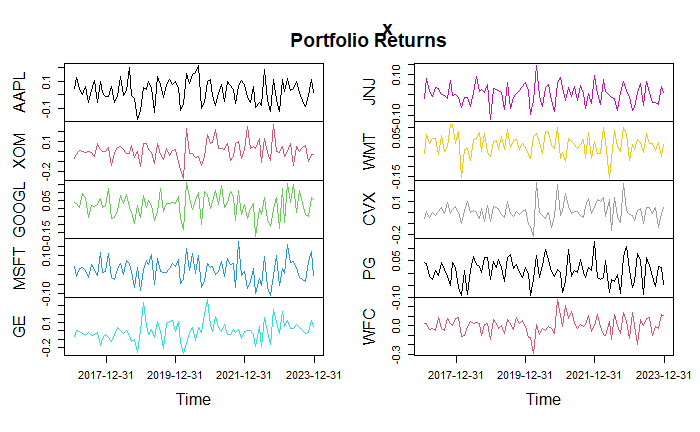

```r
plot(as.timeSeries(returns))
title("Portfolio Returns")
```

We have an idea of which stocks are growing and which are not, but that’s only part of the solution. We also need to get volatility scores. The next section builds up the formula we’ll use as part of the genetic algorithm.

```r
nStocks <- ncol(returns)   # number of portfolio assets
R <- colMeans(returns)     # average monthly returns
S <- cov(returns)          # covariance matrix of monthly returns
s <- sqrt(diag(S))         # volatility of monthly returns
```

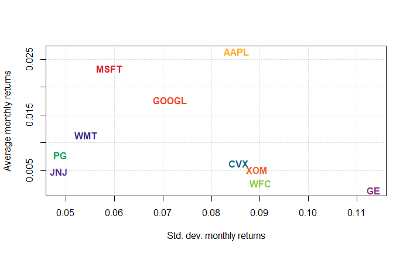

```r
plot(s, R, type = "n", panel.first = grid(), xlab = "Std. dev. monthly returns", ylab = "Average monthly returns")
text(s, R, names(R), col = .colorwheelPalette(10), font = 2)
```

This plot shows return on the y axis and volatility on the x axis. Ideally, we want stocks in the top-left portion.

Now that we have an idea of what the stocks look like, let’s build the functions we need. First up, we will build three functions, one to normalize weights, one to generate an expected return, and one to build our volatility.

```r
weights <- function(w) { drop(w/sum(w)) }
ExpReturn <- function(w) { sum(weights(w)*R) }
VarPortfolio <- function(w) {
  w <- weights(w)
  drop(w %*% S %*% w)
}
```

Note that my final formula uses 5 as a hard-coded weight. That’s a fudge factor that I’ve added in to introduce a desire for stability (reducing volatility) without completely abandoning any type of return on investment.

```r
fitness <- function(w) {
  ER <- ExpReturn(w) - 0.01
  penalty <- if(ER < 0) 100*ER^2 else 0
  ER - 5 * (VarPortfolio(w) + penalty)
}
```

Now we can run the genetic algorithm.

```r
GA <- ga(type = "real-valued", fitness = fitness,
           lower = rep(0, nStocks), upper = rep(1, nStocks), names = available_stocks,
           maxiter = 1000, run = 200, optim = TRUE)
```

```
GA | iter = 1 | Mean = -0.012619266 | Best = -0.007226273
GA | iter = 2 | Mean = -0.011101537 | Best = -0.006965802
GA | iter = 3 | Mean = -0.009526978 | Best = -0.006333863
GA | iter = 4 | Mean = -0.008701043 | Best = -0.006105567
GA | iter = 5 | Mean = -0.007870021 | Best = -0.005995415
GA | iter = 6 | Mean = -0.007353589 | Best = -0.005972446
GA | iter = 7 | Mean = -0.006814615 | Best = -0.005878633
GA | iter = 8 | Mean = -0.006563702 | Best = -0.005855669
GA | iter = 9 | Mean = -0.006404290 | Best = -0.005737933
 | Local search = -0.002133538
GA | iter = 10 | Mean = -0.006224019 | Best = -0.002133538
GA | iter = 11 | Mean = -0.006037880 | Best = -0.002133538
GA | iter = 12 | Mean = -0.005832727 | Best = -0.002133538
GA | iter = 13 | Mean = -0.006052231 | Best = -0.002133538
GA | iter = 14 | Mean = -0.005877757 | Best = -0.002133538
GA | iter = 15 | Mean = -0.005790533 | Best = -0.002133538
GA | iter = 16 | Mean = -0.005794061 | Best = -0.002133538
GA | iter = 17 | Mean = -0.005445797 | Best = -0.002133538
GA | iter = 18 | Mean = -0.005128259 | Best = -0.002133538
GA | iter = 19 | Mean = -0.004795178 | Best = -0.002133538
GA | iter = 20 | Mean = -0.004543797 | Best = -0.002133538
GA | iter = 21 | Mean = -0.004494089 | Best = -0.002133538
 | Local search = -0.002133538
GA | iter = 22 | Mean = -0.004368943 | Best = -0.002133538
GA | iter = 23 | Mean = -0.004169592 | Best = -0.002133538
GA | iter = 24 | Mean = -0.003973602 | Best = -0.002133538
GA | iter = 25 | Mean = -0.003658278 | Best = -0.002133538
GA | iter = 26 | Mean = -0.003239016 | Best = -0.002133538
GA | iter = 27 | Mean = -0.003367428 | Best = -0.002133538
GA | iter = 28 | Mean = -0.003021366 | Best = -0.002133538
GA | iter = 29 | Mean = -0.002936402 | Best = -0.002133538
 | Local search = -0.002133538
GA | iter = 30 | Mean = -0.003029529 | Best = -0.002133538
GA | iter = 31 | Mean = -0.002955605 | Best = -0.002133538
GA | iter = 32 | Mean = -0.002721998 | Best = -0.002133538
GA | iter = 33 | Mean = -0.002566647 | Best = -0.002133538
GA | iter = 34 | Mean = -0.002812334 | Best = -0.002133538
GA | iter = 35 | Mean = -0.002368193 | Best = -0.002133538
GA | iter = 36 | Mean = -0.002407848 | Best = -0.002133538
GA | iter = 37 | Mean = -0.002498680 | Best = -0.002133538
```

[output cut: 169 more lines]

```
GA | iter = 197 | Mean = -0.002274699 | Best = -0.002133538
GA | iter = 198 | Mean = -0.002473548 | Best = -0.002133538
GA | iter = 199 | Mean = -0.002380635 | Best = -0.002133538
GA | iter = 200 | Mean = -0.002217013 | Best = -0.002133538
GA | iter = 201 | Mean = -0.002330062 | Best = -0.002133538
 | Local search = -0.002133538
GA | iter = 202 | Mean = -0.002369038 | Best = -0.002133538
GA | iter = 203 | Mean = -0.002426083 | Best = -0.002133538
GA | iter = 204 | Mean = -0.002312363 | Best = -0.002133538
GA | iter = 205 | Mean = -0.002217902 | Best = -0.002133538
GA | iter = 206 | Mean = -0.002303963 | Best = -0.002133538
GA | iter = 207 | Mean = -0.002281108 | Best = -0.002133538
GA | iter = 208 | Mean = -0.002393477 | Best = -0.002133538
GA | iter = 209 | Mean = -0.002491322 | Best = -0.002133538
 | Final local search = -0.002133538
```

The genetic algorithm will run for a moment, but once it’s done, we can look at the results.

```r
summary(GA)
```

```
── Genetic Algorithm ───────────────────

GA settings:
Type                  =  real-valued
Population size       =  50
Number of generations =  1000
Elitism               =  2
Crossover probability =  0.8
Mutation probability  =  0.1
Search domain =
      AAPL XOM GOOGL MSFT GE JNJ WMT CVX PG WFC
lower    0   0     0    0  0   0   0   0  0   0
upper    1   1     1    1  1   1   1   1  1   1

GA results:
Iterations             = 209
Fitness function value = -0.002133538
Solution =
           AAPL XOM GOOGL MSFT GE JNJ       WMT CVX        PG WFC
[1,] 0.09820641   0     0    1  0   0 0.2301536   0 0.2689109   0
```

This returns some solution matrix, but these numbers are *not* the percentages of our portfolio! We need to calculate those separately in order to get the expected return.

```r
(w <- weights(GA@solution))
```

```
      AAPL        XOM      GOOGL       MSFT         GE        JNJ        WMT        CVX         PG        WFC
0.06148388 0.00000000 0.00000000 0.62606788 0.00000000 0.00000000 0.14409179 0.00000000 0.16835645 0.00000000
```

```r
ExpReturn(w)
```

```
[1] 0.01918212
```

```r
VarPortfolio(w)
```

```
[1] 0.002263131
```

And if you want a colorful bar plot which shows portfolio selections, here you go:

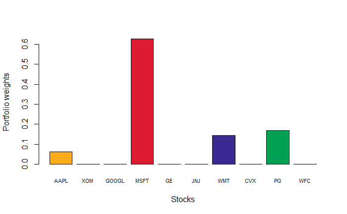

```r
barplot(w, xlab = "Stocks", ylab = "Portfolio weights",
          cex.names = 0.7, col = .colorwheelPalette(10))
```